**Research Question:** *"What predicts a positive response to Mestinon (pyridostigmine) in patient-reported data — and what does that imply for whether the drug should be formally studied?"*

# What Predicts Mestinon Response?

**Abstract.** Mestinon (pyridostigmine — a cholinesterase inhibitor approved for myasthenia gravis) is used off-label for the exercise intolerance and dysautonomia of long COVID and ME/CFS (myalgic encephalomyelitis / chronic fatigue syndrome). Pooling **1,476 patients** who discussed it across four online communities, we ask what distinguishes the roughly half who report benefit from the half who do not. The short answer: **almost nothing about the patient predicts response.** A logistic model over patient and regimen features explains little (McFadden pseudo-R² = 0.12). Its single strongest term is circular — reporting a side effect, mined from the same text that sets the outcome — and every other signal is about **how the drug was used**, not who the patient is: titrating the dose upward (the strongest clean predictor, ~2.8× the odds), multi-daily dosing, and mentioning a specific dose. No baseline patient phenotype emerged. The largest single driver of the response rate is not a patient feature at all but **which community was sampled** (31% in a chronic-illness forum vs ~50–53% elsewhere). The practical implication is that the observational "~50% works" figure is shaped by tolerability, dosing, and selection rather than a non-responder phenotype — which is precisely the ambiguity a controlled trial exists to resolve.

## 1. Why this question matters

Mestinon is a generic, off-patent drug with no commercial sponsor positioned to fund a large trial for these new uses. The conditions it is used for — long COVID, ME/CFS, dysautonomia — have essentially no approved therapies. That combination (cheap, established safety, real demand, unmet need, no commercial path) is the textbook profile of a stranded drug-repurposing candidate.

In that setting the question "what predicts response?" is not academic. If the patients who *don't* respond simply never reached an adequate dose or quit before the drug could work, then the observational "about half respond" rate **understates** the drug — and that is a fixable trial-design problem, not a reason to dismiss it. If instead non-response reflects a fixed patient phenotype, the drug is genuinely a coin flip. Distinguishing these two possibilities is the entire decision. This notebook asks how far patient-reported data can take us toward an answer — and is honest about where it cannot.

## 2. Baseline: response across four communities

Before asking *what* predicts response, we establish the overall picture. Each patient is reduced to one data point — their average sentiment across every Mestinon report they wrote — and counted a **responder** if that average is strongly positive (>0.7, i.e. their reports are predominantly positive). "Response" here means *self-reported benefit*, not a measured clinical outcome.

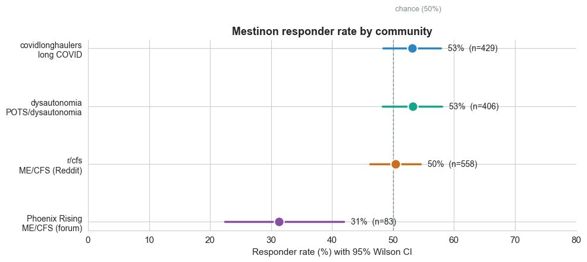

Responder rate per community (user-level)

| community | population | n_users | responder % | ci_low | ci_high |
| --- | --- | --- | --- | --- | --- |
| covidlonghaulers | long COVID | 429 | 53.100000 | 48.4 | 57.8 |
| dysautonomia | POTS/dysautonomia | 406 | 53.200000 | 48.3 | 58.0 |
| r/cfs | ME/CFS (Reddit) | 558 | 50.400000 | 46.2 | 54.5 |
| Phoenix Rising | ME/CFS (forum) | 83 | 31.300000 | 22.4 | 41.9 |

**What this shows.** Three of the four communities land in a tight ~50–53% band; the chronic-illness forum (Phoenix Rising) sits markedly lower at 31%. Crucially, the three Reddit communities span very different conditions (long COVID, POTS, ME/CFS) yet agree on the rate — so the *condition* is not what moves the number. Pooled, 50.9% of patients are responders, statistically indistinguishable from a coin flip. That "half and half" is the thing we now try to predict.

## 3. Which features track response, one at a time?

We start with simple two-group comparisons: for each patient feature, do patients *with* the feature respond at a different rate than those *without* it? Every comparison reports Fisher's exact test and Cohen's *h* (effect size for proportions). The features fall into two families — **tolerability** (whether a side effect was reported) and **regimen** (multi-daily dosing, titrating up, reaching ≥60 mg, trial length).

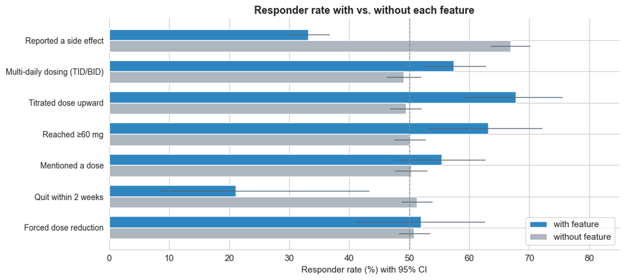

Univariate association of each feature with response

| feature | n_with | resp_with | resp_without | Fisher p | Cohen h | NNT |
| --- | --- | --- | --- | --- | --- | --- |
| Reported a side effect | 700 | 33% | 67% | 0.000 | -0.69 | nan |
| Multi-daily dosing (TID/BID) | 322 | 57% | 49% | 0.008 | +0.17 | 11.9 |
| Titrated dose upward | 118 | 68% | 49% | 0.000 | +0.38 | 5.4 |
| Reached ≥60 mg | 95 | 63% | 50% | 0.015 | +0.27 | 7.6 |
| Mentioned a dose | 168 | 55% | 50% | 0.220 | +0.10 | 19.8 |
| Quit within 2 weeks | 19 | 21% | 51% | 0.010 | -0.64 | nan |
| Forced dose reduction | 79 | 52% | 51% | 0.908 | +0.02 | 93.0 |

**What this shows.** Two genuinely positive regimen signals stand out: **titrating the dose upward** (68% vs 49% respond, p<0.001, NNT ≈ 5) and **reaching ≥60 mg** (63% vs 50%, p=0.015). Quitting within two weeks goes the other way (21% vs 51%). The single largest association is **reporting a side effect** (33% vs 67%) — but read that one carefully.

⚠ **CAUTION** — The side-effect association is partly **circular**. The side-effect field is mined from the same post text that sets the sentiment label — a post that says "it gave me cramps so I stopped" generates both a side-effect flag and a negative sentiment. So this is not independent evidence that side effects *cause* non-response; it is partly the same statement counted twice. The regimen signals (titration, dose) do not share text with the outcome and are the more trustworthy ones.

## 4. What predicts response, controlling for everything at once?

Univariate signals can be confounded — maybe people who titrate up are just from a different community. A logistic regression estimates each feature's independent contribution, holding the others (and the community) constant. Odds ratios above 1 favor response; below 1 disfavor it.

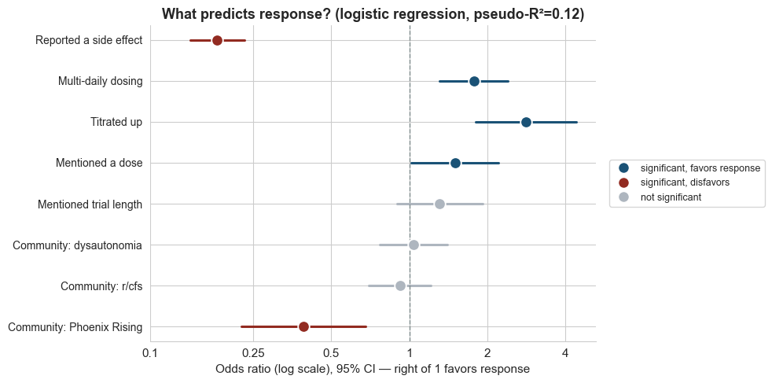

Logistic regression — n=1476, events/predictor≈83, max VIF=1.5, pseudo-R²=0.12

|  | odds_ratio | ci_low | ci_high | p |
| --- | --- | --- | --- | --- |
| Reported a side effect | 0.18 | 0.14 | 0.23 | 0.000 |
| Multi-daily dosing | 1.77 | 1.31 | 2.40 | 0.000 |
| Titrated up | 2.83 | 1.80 | 4.42 | 0.000 |
| Mentioned a dose | 1.50 | 1.02 | 2.21 | 0.041 |
| Mentioned trial length | 1.31 | 0.90 | 1.92 | 0.161 |
| Community: dysautonomia | 1.04 | 0.77 | 1.40 | 0.800 |
| Community: r/cfs | 0.92 | 0.70 | 1.21 | 0.554 |
| Community: Phoenix Rising | 0.39 | 0.23 | 0.68 | 0.001 |

## 5. The population puzzle: two ME/CFS communities disagree

Phoenix Rising and r/cfs are *both* ME/CFS communities, yet respond at 31% vs 50%. If the disease were destiny they would match. They don't — so something about the populations or how they were sampled differs. One observable correlate is overall tolerability burden: how often side effects come up at all.

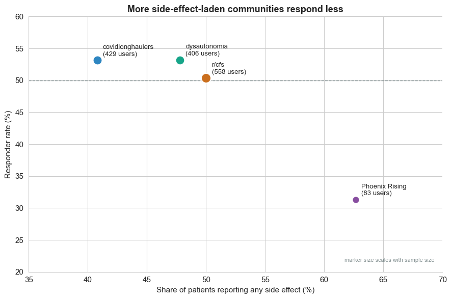

Kruskal-Wallis across communities: H=13.4, p=3.9e-03, eta-squared=0.007

| community | population | side_effect_rate | responder_rate | n |
| --- | --- | --- | --- | --- |
| covidlonghaulers | long COVID | 41% | 53% | 429 |
| dysautonomia | POTS/dysautonomia | 48% | 53% | 406 |
| r/cfs | ME/CFS (Reddit) | 50% | 50% | 558 |
| Phoenix Rising | ME/CFS (forum) | 63% | 31% | 83 |

⚠ **CAUTION** — This is a correlation across four points, not a mechanism. Higher side-effect prevalence and lower response co-occur, but we cannot say side effects *cause* the lower rate — sampling (problem-focused threads), population severity, and the circular side-effect/sentiment link could each produce the same picture. We report the pattern and stop short of explaining it.

## 6. Why this matters: the recoverable-response question

Here is the decision-relevant question hiding under "what predicts response." If a meaningful share of non-responders never got a fair trial — never titrated up, never reached an adequate dose, quit within days — then the ~50% rate is **deflated by under-treatment**, and a properly designed study would do better. To probe it, we sort patients by whether they show any *adequacy* marker (titrated up, reached ≥60 mg, multi-daily, or a trial ≥14 days) versus an *inadequacy* marker (quit within 2 weeks), leaving the rest unclassifiable.

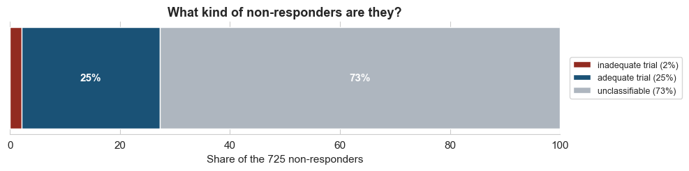

Response by trial-adequacy group | adequate vs unclassifiable: Fisher p=0.001, Cohen h=+0.19

| grp | n | responder % |
| --- | --- | --- |
| adequate trial | 436 | 58% |
| unclassifiable | 1021 | 48% |
| inadequate trial | 19 | 21% |

**What this shows — and what it cannot.** Patients showing an adequacy marker respond at **58%** vs **48%** for those with no regimen detail (p<0.01), and the tiny group who explicitly quit early respond at just 21%. That is consistent with under-treatment depressing the apparent rate. But the honest finding is the **limits**:

⛔ **UNRELIABLE** — Two reasons we **cannot** size the 'recoverable' fraction. (1) **Reverse causation:** responders stay on the drug longer and titrate up *because it is working*, so the 58% for 'adequate trial' is an optimistic ceiling, not a causal estimate. (2) **Coverage:** 73% of non-responders give no regimen detail at all, and the explicit early-quit group is only ~19 people — far too few to anchor a rate. The data raises the recoverable-response question but cannot answer it.

**Why that is the point.** An unresolved, decision-relevant ambiguity — is the ~50% a real ceiling or an under-treatment artifact? — is exactly what a controlled trial is for. And the data tells that trial what to control: mandate slow titration, multi-daily dosing, active side-effect management, and a minimum adequate duration before scoring anyone a non-responder.

To see how the inadequacy signals cluster, the heatmap below shows how often each pair of markers co-occurs within the same patient (Jaccard overlap), alongside response.

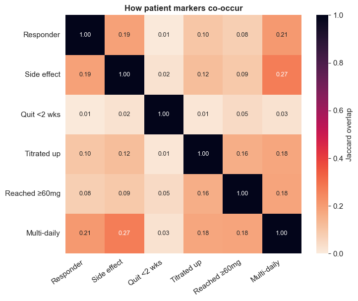

**What this shows.** The markers are largely independent — every cross-pair overlaps by less than 0.3 (Jaccard), so non-response is not one tight "inadequate-trial cluster" but a scatter of partly-overlapping situations. The early-quit marker is so rare it barely co-occurs with anything. (Jaccard counts shared patients relative to how common each marker is, so read this as "do these co-occur," not as effect size.)

## 7. Scale: this is already happening, at volume

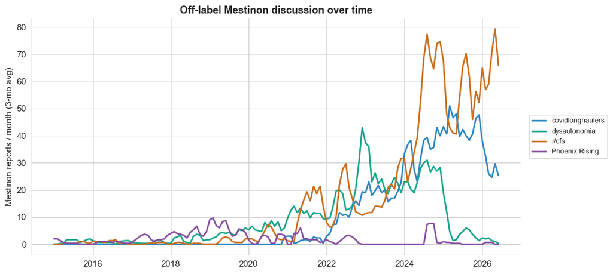

**What this shows.** Reported volume climbs steeply from 2020 as long COVID brought a wave of new patients to these drugs; r/cfs and long COVID carry the largest recent volume. (Per-community trajectories also reflect when each corpus was scraped — the late fall in some lines is a collection-window edge, not necessarily declining use.) Whatever the true response rate, a large and growing population is already making this decision without trial evidence to guide dose, titration, or who is likely to benefit.

## 8. Counterintuitive findings worth investigating

1. **The same disease, two different answers.** r/cfs and Phoenix Rising are both ME/CFS communities, yet respond at 50% vs 31% — and the gap *survives* adjustment for side effects, dosing, and titration (Phoenix odds ratio ≈ 0.39, p=0.001). A clinician would reasonably expect two ME/CFS samples to agree; they don't, and the measured clinical features don't account for it. Whether this is sampling or population severity, it is a caution against reading any single community's rate as "the" rate.
2. **"What predicts response" is mostly *how you used it* and *where you posted*, not *who you are.** The best clean predictor is a behavior (titrating up), the strongest raw correlate is circular (side-effect reporting), and the largest single driver is which community was sampled. No patient phenotype emerged. For a drug people expect to "work or not" based on their biology, that is mildly surprising — and it points at dosing and trial design rather than patient selection.

We did not find a third counterintuitive result worth the name; forcing one would weaken the two above.

## What patients are saying

Quotes are evidence, not decoration. Four below, including one that complicates the story.

*“I am almost at 10 months now. Two months ago a doctor diagnosed me with POTS. I now take mestinon 3x a day and it has helped a lot!”*

— long COVID, Dec 2020 | **clean benefit**

*“Be careful Mestinon can cause a cholinergic crisis. I love Mestinon, but I use it at a lower dose than would be ideal for my POTS, because it was causing similar side effects.”*

— long COVID, Apr 2026 | **under-dosing forced by side effects**

*“sorry for the late reply, i quit mestinon completely because the side effects were too bad compared to the benefits :(”*

— long COVID, Feb 2024 | **intolerance → discontinuation**

*“That’s what it’s suppose to do, but Mestinon did nothing for me. However it didn’t make me feel any worse.”*

— long COVID, Apr 2023 | **genuine non-response, tolerated fine**

The last quote is the honest counterweight: a patient for whom Mestinon simply did nothing, with no side effects to blame. Not every non-response is under-treatment — which is why the recoverable-response question can only be settled by a trial, not by reading more posts.

## Tiered recommendations

Graded by strength of evidence in this dataset (Strong = n≥30 and p<0.05; Moderate = n≥15 or p<0.10; Preliminary = smaller/uncertain).

[output not shown]

## Conclusion

Asked what predicts a positive Mestinon response, the most defensible answer this data supports is: **not much that lives inside the patient.** Across 1,476 people in four communities, no baseline phenotype separated the roughly half who benefited from the half who did not, and a well-powered model explained only 12% of the variation — most of it from a circular side-effect term, with the only clean signals being how the drug was dosed. Those signals are behavioral: people who describe working their dose upward respond at nearly three times the odds, and multi-daily dosing helps too.

Read together with the population puzzle — two ME/CFS communities, a 19-point gap that survives adjustment — the picture is that the observational "about half respond" figure is shaped by tolerability, dosing, and who gets sampled, not by a discoverable responder type. For a patient asking today, that means Mestinon is a reasonable, low-risk thing to try *with a clinician committed to slow titration and an adequate dose* — and that giving up in the first two weeks is the worst version of the trial. For the question of whether this off-patent drug deserves a formal study, the data makes an unusually clean case: it surfaces a real, decision-relevant ambiguity — is the 50% a ceiling or an under-treatment artifact? — that no amount of additional scraping can resolve, and it specifies exactly what a trial must control to resolve it. That is the textbook argument for a controlled trial, not against one.

## Research limitations

These findings reflect reporting patterns in online communities, not population-level treatment effects. This is not medical advice.